# Hands-on Exercise 5: Student Profile Analysis using Clustering Techniques

## 1. High-Level Outline and Background

**Problem:** Educational institutions often struggle to identify at-risk students or tailor learning experiences to individual needs due to the sheer volume of student data. The problem is to segment students into distinct groups based on their academic, demographic, and socio-economic profiles to understand underlying patterns.

**Importance:** By identifying these patterns, institutions can move from a "one-size-fits-all" approach to personalized interventions. This can lead to improved student retention, better academic performance, and more efficient allocation of resources (e.g., financial aid or counseling).

**Key Stakeholders:**

- **University Administration:** Interested in retention rates and resource allocation.
- **Academic Advisors:** Need to identify students requiring support.
- **Students:** Beneficiaries of targeted support and personalized learning paths.
- **Faculty:** Can adapt teaching strategies based on class profiles.

## 2. Data Preparation and EDA

In this section, we load the dataset, check for missing values, perform exploratory data analysis (EDA), and normalize the features to prepare them for clustering.

```python
import os
from google.colab import drive

# 1. Mount Google Drive
drive.mount('/content/drive')

# 2. Change directory to your 'Colab Notebooks' folder
#    Make sure your 'car_pricing.csv' file is in this folder
%cd /content/drive/MyDrive/Colab Notebooks

# 3. Verify the current directory
print(f"Current working directory: {os.getcwd()}")
```

```
/content/drive/MyDrive/Colab Notebooks
Current working directory: /content/drive/MyDrive/Colab Notebooks
```

```
Missing Values per column:
Marital status                                    0
Application mode                                  0
Application order                                 0
Course                                            0
Daytime/evening attendance                        0
Previous qualification                            0
Previous qualification (grade)                    0
Nacionality                                       0
Mother's qualification                            0
Father's qualification                            0
Mother's occupation                               0
Father's occupation                               0
Admission grade                                   0
Displaced                                         0
Educational special needs                         0
Debtor                                            0
Tuition fees up to date                           0
Gender                                            0
Scholarship holder                                0
Age at enrollment                                 0
International                                     0
Curricular units 1st sem (credited)               0
Curricular units 1st sem (enrolled)               0
Curricular units 1st sem (evaluations)            0
Curricular units 1st sem (approved)               0
Curricular units 1st sem (grade)                  0
Curricular units 1st sem (without evaluations)    0
Curricular units 2nd sem (credited)               0
Curricular units 2nd sem (enrolled)               0
Curricular units 2nd sem (evaluations)            0
Curricular units 2nd sem (approved)               0
Curricular units 2nd sem (grade)                  0
Curricular units 2nd sem (without evaluations)    0
Unemployment rate                                 0
Inflation rate                                    0
GDP                                               0
dtype: int64
<class 'pandas.core.frame.DataFrame'>
RangeIndex: 4424 entries, 0 to 4423
```

[output cut: 178 more lines]

```
Curricular units 1st sem (credited)               20.000000
Curricular units 1st sem (enrolled)               26.000000
Curricular units 1st sem (evaluations)            45.000000
Curricular units 1st sem (approved)               26.000000
Curricular units 1st sem (grade)                  18.875000
Curricular units 1st sem (without evaluations)    12.000000
Curricular units 2nd sem (credited)               19.000000
Curricular units 2nd sem (enrolled)               23.000000
Curricular units 2nd sem (evaluations)            33.000000
Curricular units 2nd sem (approved)               20.000000
Curricular units 2nd sem (grade)                  18.571429
Curricular units 2nd sem (without evaluations)    12.000000
Unemployment rate                                 16.200000
Inflation rate                                     3.700000
GDP                                                3.510000
```

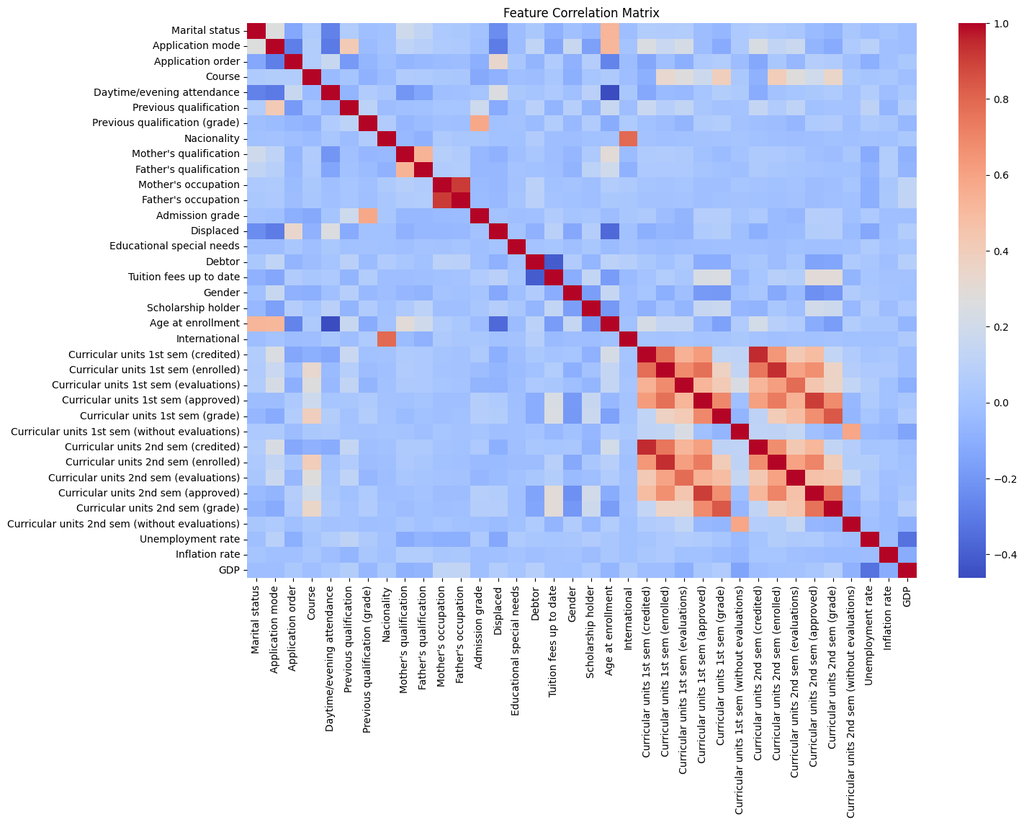

|  | Marital status | Application mode | Application order | Course | Daytime/evening attendance | Previous qualification | Previous qualification (grade) | Nacionality | Mother's qualification | Father's qualification | ... | Curricular units 1st sem (without evaluations) | Curricular units 2nd sem (credited) | Curricular units 2nd sem (enrolled) | Curricular units 2nd sem (evaluations) | Curricular units 2nd sem (approved) | Curricular units 2nd sem (grade) | Curricular units 2nd sem (without evaluations) | Unemployment rate | Inflation rate | GDP |
| --- | --- | --- | --- | --- | --- | --- | --- | --- | --- | --- | --- | --- | --- | --- | --- | --- | --- | --- | --- | --- | --- |
| 0 | -0.294829 | -0.095470 | 2.490896 | -4.209520 | 0.350082 | -0.35023 | -0.804841 | -0.126298 | -0.036018 | -0.669778 | ... | -0.199273 | -0.282442 | -2.838337 | -2.042630 | -1.471527 | -1.963489 | -0.199441 | -0.287638 | 0.124386 | 0.765761 |
| 1 | -0.294829 | -0.209869 | -0.554068 | 0.192580 | 0.350082 | -0.35023 | 2.076819 | -0.126298 | -1.189759 | -1.256427 | ... | -0.199273 | -0.282442 | -0.105726 | -0.522682 | 0.518904 | 0.659562 | -0.199441 | 0.876222 | -1.105222 | 0.347199 |
| 2 | -0.294829 | -1.010660 | 2.490896 | 0.103404 | 0.350082 | -0.35023 | -0.804841 | -0.126298 | 1.117723 | 0.959802 | ... | -0.199273 | -0.282442 | -0.105726 | -2.042630 | -1.471527 | -1.963489 | -0.199441 | -0.287638 | 0.124386 | 0.765761 |
| 3 | -0.294829 | -0.095470 | 0.207173 | 0.444115 | 0.350082 | -0.35023 | -0.804841 | -0.126298 | 1.181819 | 0.959802 | ... | -0.199273 | -0.282442 | -0.105726 | 0.490616 | 0.187165 | 0.416450 | -0.199441 | -0.813253 | -1.466871 | -1.375511 |
| 4 | 1.356212 | 1.162916 | -0.554068 | -0.408389 | -2.856470 | -0.35023 | -2.473171 | -0.126298 | 1.117723 | 1.024985 | ... | -0.199273 | -0.282442 | -0.105726 | -0.522682 | 0.518904 | 0.531608 | -0.199441 | 0.876222 | -1.105222 | 0.347199 |

5 rows × 36 columns

```python
import pandas as pd
import numpy as np
import matplotlib.pyplot as plt
import seaborn as sns
from sklearn.preprocessing import StandardScaler
from sklearn.decomposition import PCA
from sklearn.cluster import KMeans, AgglomerativeClustering, DBSCAN
from sklearn.metrics import silhouette_score
from scipy.cluster.hierarchy import dendrogram, linkage

# Load the dataset
df = pd.read_csv('Studentnfo.csv')

# 1. Handle Missing Values
print("Missing Values per column:")
print(df.isnull().sum())
# If there were missing values, we would fill them (e.g., df.fillna(df.mean(), inplace=True))

# 2. Transform Categorical Variables
# Check data types
print(df.info())
# Note: In this dataset, categorical variables (like Marital status, Course) are already integer-encoded.
# For clustering, we will treat them as numerical features, but we must scale them.

# 3. Conduct EDA
print(df.describe().T)

# Visualize correlation to understand relationships
plt.figure(figsize=(15, 10))
sns.heatmap(df.corr(), cmap='coolwarm', annot=False)
plt.title("Feature Correlation Matrix")
plt.show()

# 4. Data Normalization
# Scaling is crucial for clustering so that features with larger ranges (like GDP) don't dominate.
scaler = StandardScaler()
df_scaled = pd.DataFrame(scaler.fit_transform(df), columns=df.columns)
df_scaled.head()
```

## 3.1 KMeans Model

We will determine the optimal number of clusters ($K$) using the Elbow Method and Silhouette Scores, and then visualize the results.

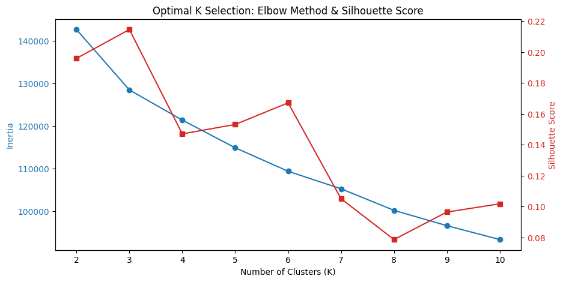

```
Optimal K chosen: 3
```

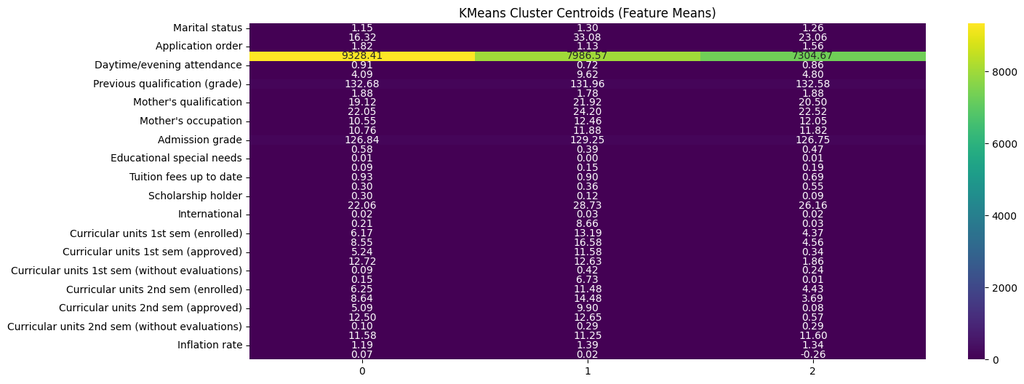

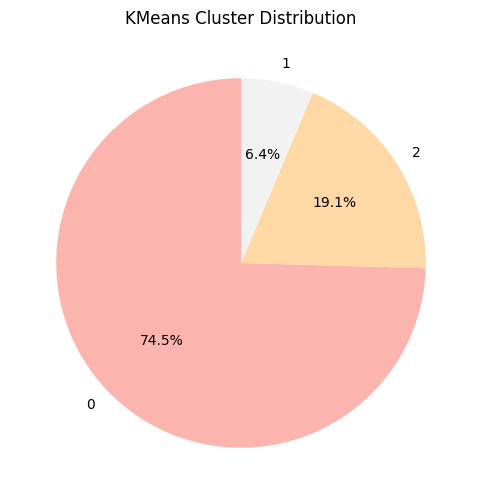

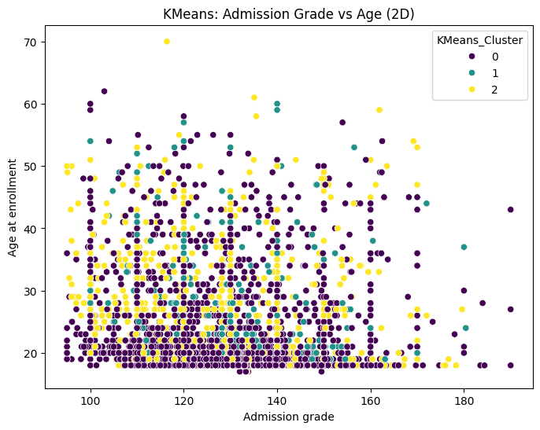

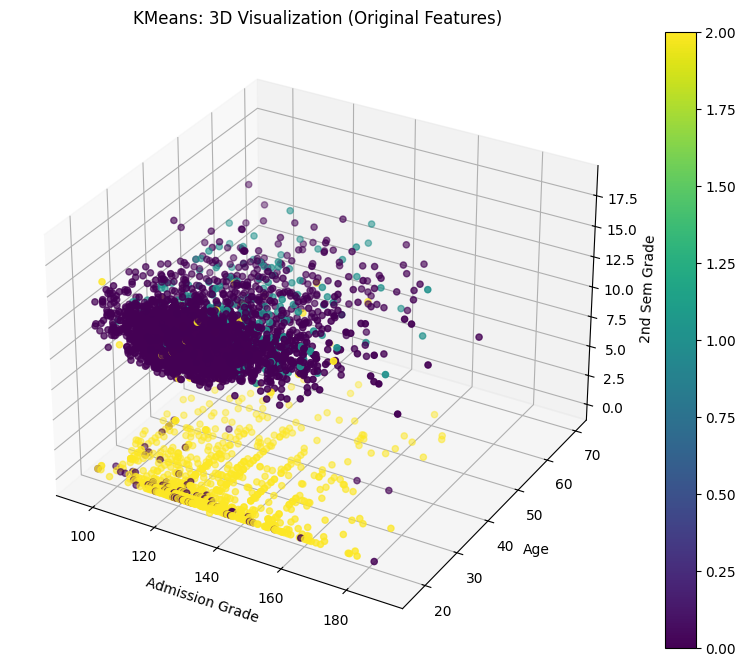

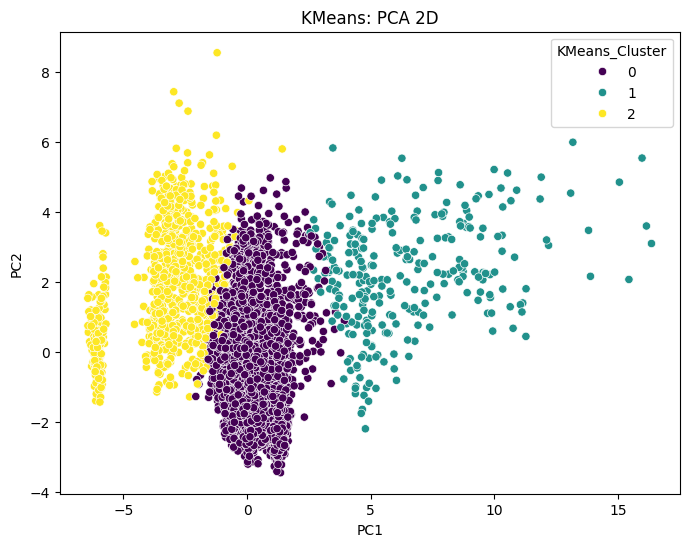

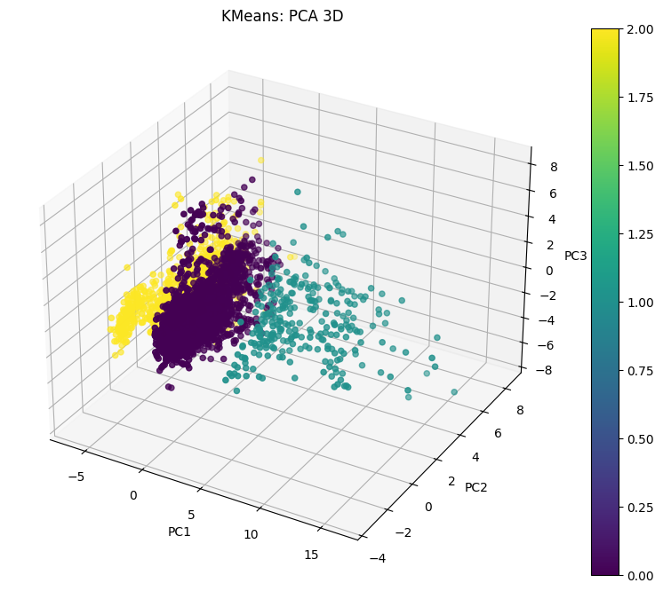

```python
# --- Optimal K Selection ---
inertias = []
sil_scores = []
K_range = range(2, 11)

for k in K_range:
    kmeans = KMeans(n_clusters=k, random_state=42, n_init=10)
    kmeans.fit(df_scaled)
    inertias.append(kmeans.inertia_)
    sil_scores.append(silhouette_score(df_scaled, kmeans.labels_))

# Plot Elbow Method and Silhouette Scores
fig, ax1 = plt.subplots(figsize=(10, 5))

ax1.set_xlabel('Number of Clusters (K)')
ax1.set_ylabel('Inertia', color='tab:blue')
ax1.plot(K_range, inertias, marker='o', color='tab:blue', label='Inertia')
ax1.tick_params(axis='y', labelcolor='tab:blue')

ax2 = ax1.twinx()
ax2.set_ylabel('Silhouette Score', color='tab:red')
ax2.plot(K_range, sil_scores, marker='s', color='tab:red', label='Silhouette Score')
ax2.tick_params(axis='y', labelcolor='tab:red')

plt.title('Optimal K Selection: Elbow Method & Silhouette Score')
plt.show()

# Based on the plot (usually highest Silhouette or "elbow" of inertia), let's say K=3 is chosen.
best_k = 3
print(f"Optimal K chosen: {best_k}")

# --- KMeans Clustering ---
kmeans_final = KMeans(n_clusters=best_k, random_state=42, n_init=10)
df['KMeans_Cluster'] = kmeans_final.fit_predict(df_scaled)

# --- Centroid Information ---
# Inverse transform to interpret centroids in original scale
centroids = scaler.inverse_transform(kmeans_final.cluster_centers_)
centroids_df = pd.DataFrame(centroids, columns=df.columns[:-1]) # Exclude the cluster label column we just added

plt.figure(figsize=(15, 6))
sns.heatmap(centroids_df.T, annot=True, cmap='viridis', fmt='.2f')
plt.title('KMeans Cluster Centroids (Feature Means)')
plt.show()

# --- Cluster Distribution ---
plt.figure(figsize=(6, 6))
df['KMeans_Cluster'].value_counts().plot.pie(autopct='%1.1f%%', startangle=90, cmap='Pastel1')
plt.title('KMeans Cluster Distribution')
plt.ylabel('')
plt.show()

# --- Visualization (Original Features) ---
# Picking 2 features: Admission grade vs. Age
plt.figure(figsize=(8, 6))
sns.scatterplot(data=df, x='Admission grade', y='Age at enrollment', hue='KMeans_Cluster', palette='viridis')
plt.title('KMeans: Admission Grade vs Age (2D)')
plt.show()

# Picking 3 features: Admission grade, Age, Curricular units 2nd sem (grade)
fig = plt.figure(figsize=(10, 8))
ax = fig.add_subplot(111, projection='3d')
sc = ax.scatter(df['Admission grade'], df['Age at enrollment'], df['Curricular units 2nd sem (grade)'],
                c=df['KMeans_Cluster'], cmap='viridis')
ax.set_xlabel('Admission Grade')
ax.set_ylabel('Age')
ax.set_zlabel('2nd Sem Grade')
plt.title('KMeans: 3D Visualization (Original Features)')
plt.colorbar(sc)
plt.show()

# --- Visualization (PCA) ---
pca = PCA(n_components=3)
pca_components = pca.fit_transform(df_scaled)

# 2D PCA
plt.figure(figsize=(8, 6))
sns.scatterplot(x=pca_components[:, 0], y=pca_components[:, 1], hue=df['KMeans_Cluster'], palette='viridis')
plt.title('KMeans: PCA 2D')
plt.xlabel('PC1')
plt.ylabel('PC2')
plt.show()

# 3D PCA
fig = plt.figure(figsize=(10, 8))
ax = fig.add_subplot(111, projection='3d')
sc = ax.scatter(pca_components[:, 0], pca_components[:, 1], pca_components[:, 2],
                c=df['KMeans_Cluster'], cmap='viridis')
ax.set_xlabel('PC1')
ax.set_ylabel('PC2')
ax.set_zlabel('PC3')
plt.title('KMeans: PCA 3D')
plt.colorbar(sc)
plt.show()
```